# Evaluate streamflow simulation with rwrfhydro

Aubrey Dugger and James McCreight

2016-05-03

# Background

Load the rwrfhydro package.

```r
library("rwrfhydro")
```

Set a data path to the Fourmile Creek test case.

```r
dataPath <- '~/wrfHydroTestCases/Fourmile_Creek_testcase_v2.0/'
```

# Import modelled and observed datasets

Model 1: Only channel routing turned on (hourly model run).

```r
modStrd.chrt.fc <- ReadFrxstPts(paste0(dataPath, '/run.ChannelRouting/frxst_pts_out.txt'))
```

Model 2: All WRF-Hydro routing options turned on (hourly model run).

```r
modStrd.allrt.fc <- ReadFrxstPts(paste0(dataPath, '/run.FullRouting/frxst_pts_out.txt'))
```

USGS gage observed data at 5-minute intervals. Find the nearest gage to the forecast point in the above files. (The following approach can be used when multiple forecast points are output by the model. The ddply function essentially performs a loop over unique st_id passing the corresponding subset of the data frame modStrd.chrt.fc to the function which just returns the first row’s lon and lat.)

```r
library(plyr)
fcLocation <- ddply(modStrd.chrt.fc, .(st_id), function(df) df[1,c('st_lon','st_lat')])
near <- FindUsgsStns(stnLon=c(fcLocation$st_lon), stnLat=c(fcLocation$st_lat), within=.005)
near
```

| stnLon | stnLat | within | siteType | hasDataTypeCd | agency_cd | site_no | station_nm | site_tp_cd | dec_lat_va | dec_long_va | queryTime |
| --- | --- | --- | --- | --- | --- | --- | --- | --- | --- | --- | --- |
| -105.3278 | 40.01932 | 0.005 | ST | iv | USGS | 06727500 | FOURMILE CREEK AT ORODELL, CO | ST | 40.01867 | -105.3263 | 2016-05-03 19:34:43 |

The following checks to see if the data are local and gets them if not. The ‘00060’ product (streamflow) is returned and then made pretty, including conversion to metric.

```r
dbPath <- '~/wrfHydroTestCases/usgsDb/'
obsStr5min.fc <-
  PrettyUsgs(QueryHaveSite(near$site_no, path=dbPath, ret='00060', get=TRUE))
names(obsStr5min.fc)[4] <- 'q_cms'
```

# Plot hydrographs

Compare hydrographs for the full model run.

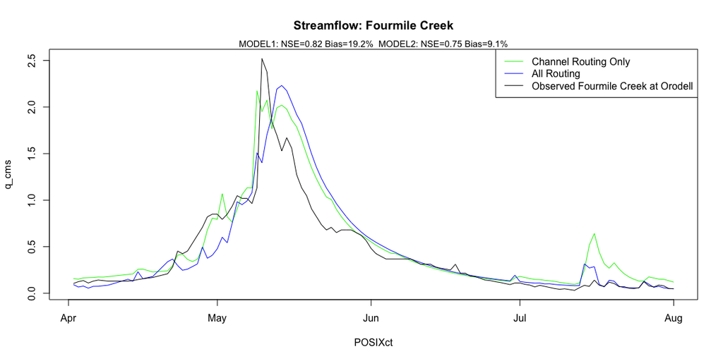

```r
PlotFluxCompare(obsStr5min.fc, "q_cms", modStrd.chrt.fc, "q_cms", strDf.mod2=modStrd.allrt.fc,
     strCol.mod2="q_cms", labelObs="Observed Fourmile Creek at Orodell",
     labelMod1="Channel Routing Only", labelMod2="All Routing",
     title="Streamflow: Fourmile Creek")
```

Now limit the plot to the peak May flow period only. The reported stats are updated to the new time period. (Note that the R warning is innocuous because the subset adjusts for timezone, so it’s ok that the timezones don’t match.)

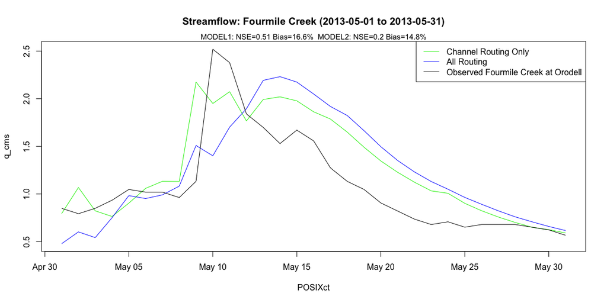

```r
PlotFluxCompare(obsStr5min.fc, "q_cms", modStrd.chrt.fc, "q_cms", strDf.mod2=modStrd.allrt.fc,
     strCol.mod2="q_cms", labelObs="Observed Fourmile Creek at Orodell",
     labelMod1="Channel Routing Only", labelMod2="All Routing",
     title="Streamflow: Fourmile Creek",
     stdate=as.POSIXct("2013-05-01 00:00:00", format="%Y-%m-%d %H:%M:%S", tz="UTC"),
     enddate=as.POSIXct("2013-05-31 00:00:00", format="%Y-%m-%d %H:%M:%S", tz="UTC"))
```

# Review flow duration curves

**NOTE**: You generally evaluate flow duration curves and staistics over much longer time periods (e.g., multiple years) than what we demo here. To make the test case more portable, we are only evaluating once-a-day model output over 5 months.

Calculate percent exceedances for flow duration curves. Note that we need to subset the observations to match our model run output times, and vice versa.

```r
obsStr5min.comp.fc <- CalcFdc(subset(obsStr5min.fc, POSIXct %in% c(modStrd.chrt.fc$POSIXct)))
modStrd.chrt.comp.fc <- CalcFdc(subset(modStrd.chrt.fc, POSIXct %in% c(obsStr5min.comp.fc$POSIXct)))
modStrd.allrt.comp.fc <- CalcFdc(subset(modStrd.allrt.fc, POSIXct %in% c(obsStr5min.comp.fc$POSIXct)))
```

Compare how the models are doing predicting flow values that will be exceeded 20% of the time. First, calculate the fitted spline functions.

```r
fdc.obsStr5min.comp.fc <- CalcFdcSpline(obsStr5min.comp.fc)
fdc.modStrd.chrt.comp.fc <- CalcFdcSpline(modStrd.chrt.comp.fc)
fdc.modStrd.allrt.comp.fc <- CalcFdcSpline(modStrd.allrt.comp.fc)
```

Then, evaluate at the 20% exceedance percentage (high flows).

```r
fdc.obsStr5min.comp.fc(0.2)
fdc.modStrd.chrt.comp.fc(0.2)
fdc.modStrd.allrt.comp.fc(0.2)
```

```
## [1] 0.7706495
## [1] 0.8170807
## [1] 0.7931814
```

Now try the 80% exceedance percentage (low flows).

```r
fdc.obsStr5min.comp.fc(0.8)
fdc.modStrd.chrt.comp.fc(0.8)
fdc.modStrd.allrt.comp.fc(0.8)
```

```
## [1] 0.08530777
## [1] 0.1557625
## [1] 0.09120762
```

Plot flow duration curves for a more complete picture. This tool will do the date matching for us, so no need to subset the datasets.

```
## [1] "Combined min flow for y-axis (capped at 0.001): 0.03114853126"
## [1] "Combined max flow for y-axis: 2.5201993474"
```

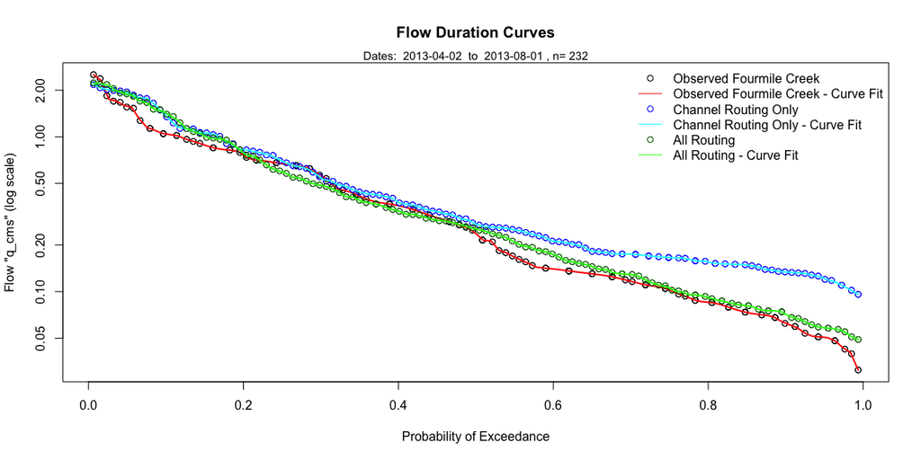

```r
PlotFdcCompare(obsStr5min.fc, "q_cms", modStrd.chrt.fc, "q_cms", strDf.mod2=modStrd.allrt.fc,
     strCol.mod2="q_cms", labelObs="Observed Fourmile Creek",
     labelMod1="Channel Routing Only", labelMod2="All Routing")
```

# Review model performance statistics

Calculate model performance stats (special formatting comands hidden). Again, this tool does the date matching for us.

```r
CalcModPerf(modStrd.chrt.fc, obsStr5min.fc)
```

|  | n | nse | nselog | cor | rmse | rmsenorm | bias | msd | mae | errcom | errmaxt | errfdc |
| --- | --- | --- | --- | --- | --- | --- | --- | --- | --- | --- | --- | --- |
| **units** | count | unitless | unitless | unitless | flux units | unitless | percent | flux units | flux units | hours\|days | hours\|days | flux units |
| **t** | 232 | 0.82 | 0.73 | 0.93 | 0.2067 | 8.31 | 19.2 | 0.0846 | 0.1305 | NA | NA | 0.08 |
| **daily** | 116 | 0.82 | 0.73 | 0.93 | 0.2067 | 8.31 | 19.2 | 0.0846 | 0.1305 | 0 | 0 | 0.08 |
| **monthly** | 5 | 0.92 | 0.7 | 0.99 | 0.1044 | 10.07 | 21.5 | 0.0768 | 0.0806 | -0.2 | -0.2 | NA |
| **yearly** | 1 | NA | NA | NA | NA | NA | 19.2 | 0.0846 | 0.0846 | 3 | -1 | NA |
| **max10** | 24 | -0.04 | -0.08 | 0.5 | 0.4806 | 32.64 | 15 | 0.235 | 0.417 | NA | NA | NA |
| **min10** | 24 | -82.69 | -24.6 | 0.53 | 0.078 | 250.56 | 152.6 | 0.076 | 0.076 | NA | NA | NA |

```r
CalcModPerf(modStrd.allrt.fc, obsStr5min.fc)
```

|  | n | nse | nselog | cor | rmse | rmsenorm | bias | msd | mae | errcom | errmaxt | errfdc |
| --- | --- | --- | --- | --- | --- | --- | --- | --- | --- | --- | --- | --- |
| **units** | count | unitless | unitless | unitless | flux units | unitless | percent | flux units | flux units | hours\|days | hours\|days | flux units |
| **t** | 116 | 0.75 | 0.87 | 0.9 | 0.2462 | 9.89 | 9.1 | 0.0399 | 0.1402 | NA | NA | 0.03 |
| **daily** | 116 | 0.75 | 0.87 | 0.9 | 0.2462 | 9.89 | 9.1 | 0.0399 | 0.1402 | 0 | 0 | 0.03 |
| **monthly** | 5 | 0.95 | 0.95 | 0.99 | 0.0867 | 8.36 | 7 | 0.0251 | 0.0645 | -0.6 | 0 | NA |
| **yearly** | 1 | NA | NA | NA | NA | NA | 9.1 | 0.0399 | 0.0399 | 3 | 4 | NA |
| **max10** | 12 | -0.63 | -0.51 | 0.11 | 0.6034 | 40.98 | 14.4 | 0.2264 | 0.5365 | NA | NA | NA |
| **min10** | 12 | -13.12 | -6.56 | -0.08 | 0.0321 | 102.9 | 49.8 | 0.0248 | 0.0252 | NA | NA | NA |

Help on CalcModPerf gives details on the individual statistics returned.

```r
help(CalcModPerf)
```

| CalcModPerf | R Documentation |
| --- | --- |

## Computes model performance statistics for WRF-Hydro flux output

### Description

`CalcModPerf` calculates model performance statistics for flux output.

### Usage

```r
CalcModPerf(flxDf.mod, flxDf.obs, flxCol.mod = "q_cms",
  flxCol.obs = "q_cms", stdate = NULL, enddate = NULL,
  subdivisions = 1000)
```

### Arguments

| `flxDf.mod` | The flux output dataframe (required). Assumes only one forecast point per file, so if you have multiple forecast points in your output dataframe, use subset to isolate a single forecast point’s data. … |
| --- | --- |
| `flxDf.obs` | The observed flux dataframe. Assumes only one observation point per file, so if you have multiple observation points in your dataframe, use subset to isolate a single point’s data. Also assumes model … |
| `flxCol.mod` | The column name for the flux time series for the MODEL data (default=“q_cms”) |
| `flxCol.obs` | The column name for the flux time series for the OBSERVED data (default=“q_cms”) |
| `stdate` | Start date for statistics (DEFAULT=NULL, all records will be used). Date MUST be specified in POSIXct format with appropriate timezone (e.g., as.POSIXct(“2013-05-01 00:00:00”, format=“%Y-%m-%d %H:%M:%… |
| `enddate` | End date for statistics (DEFAULT=NULL, all records will be used). Date MUST be specified in POSIXct format with appropriate timezone (e.g., as.POSIXct(“2013-05-01 00:00:00”, format=“%Y-%m-%d %H:%M:%S”… |
| `subdivisions` | Number of subdivisions used in flow duration curve integration (DEFAULT=1000); increase value if integrate function throws an error. |

### Details

`CalcModPerf` reads a model flux time series (i.e., created using `ReadFrxstPts`) and an observation time series (i.e., created using `ReadUsgsGage`) and calculates model performance statistics (Nash-Sutcliffe Efficiency, Rmse, etc.) at various time scales and for low and high fluxes. The tool will subset data to matching time periods (e.g., if the observed data is at 5-min increments and modelled data is at 1-hr increments, the tool will subset the observed data to select only observations on the matching hour break).

Performance Statistics:  
(mod = model output, obs = observations, n = sample size)

- n: sample size
- nse: Nash-Sutcliffe Efficiency

  *nse = 1 - ( sum((obs - mod)^2) / sum((obs - mean(obs))^2) )*
- nselog: log-transformed Nash-Sutcliffe Efficiency

  *nselog = 1 - ( sum((log(obs) - log(mod))^2) / sum((log(obs) - mean(log(obs)))^2) )*
- cor: correlation coefficient

  *cor = cor(mod, obs)*
- rmse: root mean squared error

  *rmse = sqrt( sum((mod - obs)^2) / n )*
- rmsenorm: normalized root mean squared error

  *rmsenorm = rmse / (max(obs) - min(obs))*
- bias: percent bias

  *bias = sum(mod - obs) / sum(obs) * 100*
- msd: mean signed deviation

  *msd = mean(mod - obs)*
- mae: mean absolute error

  *mae = mean(abs(mod - obs))*
- errcom: error in the center-of-mass of the flux, where center-of-mass is the hour/day when 50% of daily/monthly/water-year flux has occurred. Reported as number of hours for daily time scale and number of days for monthly and yearly time scales.
- errmaxt: Error in the time of maximum flux. Reported as number of hours for daily time scale and number of days for monthly and yearly time scales).
- errfdc: Error in the integrated flow duration curve between 0.05 and 0.95 exceedance thresholds (in native flow units).

Time scales/Flux types:

- ts = native model/observation time step (e.g., hourly)
- daily = daily time step
- monthly = monthly time step
- yearly = water-year time step
- max10 = high flows; restricted to the portion of the time series where the observed flux is in the highest 10% (native time step)
- min10 = low flows; restricted to the portion of the time series where the observed flux is in the lowest 10% (native time step)

### Value

A new dataframe containing the model performance statistics.

### See Also

Other modelEvaluation: `CalcMetContGrid`, `CalcMetCont`, `CalcModPerfMulti`, `CalcNoahmpFluxes`, `CalcNoahmpWatBudg`, `CalcStatCategorical`, `CalcStatCont`

### Examples

```r
## Take forecast point model output for Fourmile Creek (modStrh.mod1.fc) and a
## corresponding USGS gage observation file (obsStrh.fc), both at an hourly time step,
## and calculate model performance statistics. The model forecast point data was
## imported using ReadFrxstPts and the gage observation data was imported using
## ReadUsgsGage.


## Not run:
CalcModPerf(modStrd.chrt.fc, obsStr5min.fc)

> Output:
            n      nse   nselog      cor       rmse rmsenorm    bias        msd        mae     errcom    errmaxt     errfdc
units   count unitless unitless unitless flux units unitless percent flux units flux units hours|days hours|days flux units
t         116     0.81     0.67     0.91      0.211     8.48     7.1     0.0313     0.1385       <NA>       <NA>       0.04
daily     116     0.81     0.67     0.91      0.211     8.48     7.1     0.0313     0.1385          0          0       0.04
monthly     5     0.92     0.82     0.96     0.1073    10.35     9.1     0.0324     0.0833       -1.2        0.2       <NA>
yearly      1     <NA>     <NA>     <NA>       <NA>     <NA>     7.1     0.0313     0.0313          0          4       <NA>
max10      12     0.46     0.58     0.71      0.348    23.63    -2.8     -0.044      0.248       <NA>       <NA>       <NA>
min10      12  -385.99   -14.59     0.35     0.1678   538.78   112.4      0.056     0.0592       <NA>       <NA>       <NA>

## End(Not run)
```

Calculate flow duration curve performance statistics.

```r
CalcFdcPerf(modStrd.allrt.fc, obsStr5min.fc)
```

| p.exceed | q.mod | q.obs | q.err | q.perr |
| --- | --- | --- | --- | --- |
| 0.1 | 1.43 | 1.04 | 0.39 | 37.5 |
| 0.2 | 0.79 | 0.77 | 0.02 | 2.6 |
| 0.3 | 0.49 | 0.56 | -0.07 | -12.5 |
| 0.4 | 0.33 | 0.36 | -0.03 | -8.3 |
| 0.5 | 0.25 | 0.24 | 0.01 | 4.2 |
| 0.6 | 0.17 | 0.14 | 0.03 | 21.4 |
| 0.7 | 0.13 | 0.12 | 0.01 | 8.3 |
| 0.8 | 0.09 | 0.09 | 0 | 0 |
| 0.9 | 0.07 | 0.06 | 0.01 | 16.7 |

Again, help on CalcFdcPerf gives details on the individual statistics returned.

```r
help(CalcFdcPerf)
```

| CalcFdcPerf | R Documentation |
| --- | --- |

## Computes flow duration curve statistics for WRF-Hydro streamflow output

### Description

`CalcFdcPerf` calculates flow duration curve statistics for streamflow output.

### Usage

```r
CalcFdcPerf(strDf.mod, strDf.obs, strCol.mod = "q_cms",
  strCol.obs = "q_cms", stdate = NULL, enddate = NULL)
```

### Arguments

| `strDf.mod` | The forecast point output dataframe (required). Assumes only one forecast point per file, so if you have multiple forecast points in your output dataframe, use subset to isolate a single forecast poin… |
| --- | --- |
| `strDf.obs` | The observed streamflow dataframe. Assumes only one gage per file, so if you have multiple gages in your dataframe, use subset to isolate a single gage’s data. Also assumes model output and observatio… |
| `strCol.mod` | The column name for the streamflow time series for the MODEL data (default=“q_cms”) |
| `strCol.obs` | The column name for the streamflow time series for the OBSERVED data (default=“q_cms”) |
| `stdate` | Start date for statistics (DEFAULT=NULL, all records will be used). Date MUST be specified in POSIXct format with appropriate timezone (e.g., as.POSIXct(“2013-05-01 00:00:00”, format=“%Y-%m-%d %H:%M:%… |
| `enddate` | End date for statistics (DEFAULT=NULL, all records will be used). Date MUST be specified in POSIXct format with appropriate timezone (e.g., as.POSIXct(“2013-05-01 00:00:00”, format=“%Y-%m-%d %H:%M:%S”… |

### Details

`CalcFdcPerf` reads a model forecast point streamflow timeseries (i.e., created using `ReadFrxstPts`) and a streamflow observation timeseries (i.e., created using `ReadUsgsGage`) and calculates flow duration curve statistics at various exceedance thresholds (e.g., 10%, 20%, etc.). The tool will subset data to matching time periods (e.g., if the observed data is at 5-min increments and modelled data is at 1-hr increments, the tool will subset the observed data to select only observations on the matching hour break).

Flow Duration Curve Statistics:  
(mod = model output, obs = observations)

- p.exceed: exceedance threshold (e.g., 0.2 means a flow value that is exceeded 20% of the time)
- q.mod: MODEL flow value at specified exceedance threshold (in native flow units)
- q.obs: OBSERVED flow value at specified exceedance threshold (in native flow units)
- q.err: difference between model and observed flow values [mod-obs] (in native flow units)
- q.perr: percent error in model flow [(mod-obs)/obs]

### Value

A new dataframe containing the flow duration curve statistics.

### Examples

```r
## Take forecast point model output for Fourmile Creek (modStrh.mod1.fc)
## and a corresponding USGS gage observation file (obsStrh.fc), both at an
## hourly time step, and calculate flow duration curve statistics. The
## model forecast point data was imported using ReadFrxstPts and the gage
## observation data was imported using ReadUsgsGage.

## Not run:
CalcFdcPerf(modStr1h.allrt.fc, obsStr5min.fc)

Output:
 p.exceed    q.mod   q.obs
 0.1         3.07    5.25
 0.2         1.35    2.31
 0.3         0.82    1.06
 0.4         0.48    0.65
 0.5         0.29    0.45
 0.6         0.18    0.34
 0.7         0.14    0.25
 0.8         0.11    0.19
 0.9         0.08    0.16

## End(Not run)
```